# INTRODUCTION TO GGPLOT2: GEOMETRIES

There are three position options for bar plots:

- `stack`: default

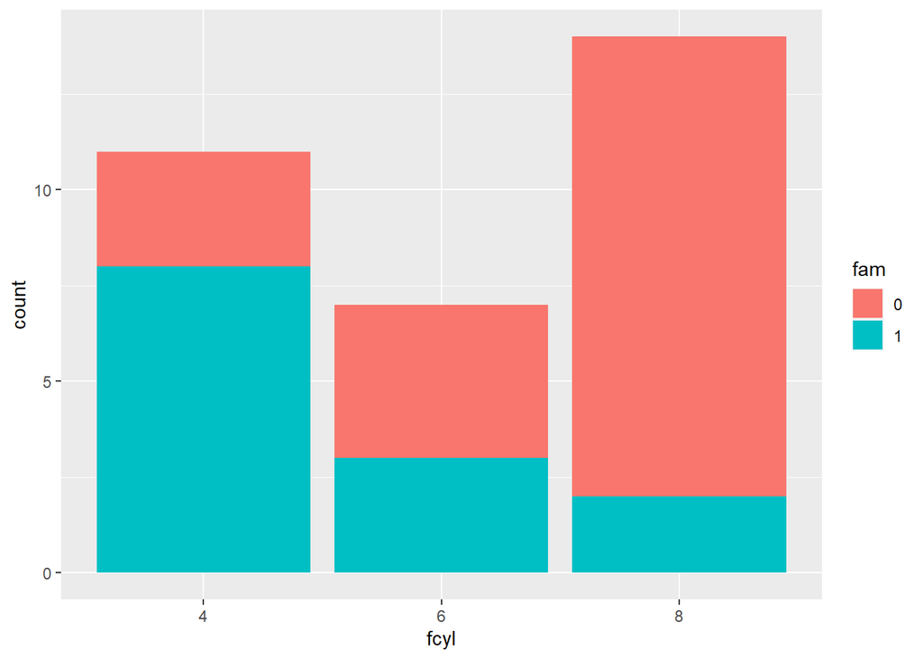

```r
ggplot(mtcars, aes(fcyl,
                   fill = fam)) +
  geom_bar()
```

- `dodge`: prefered

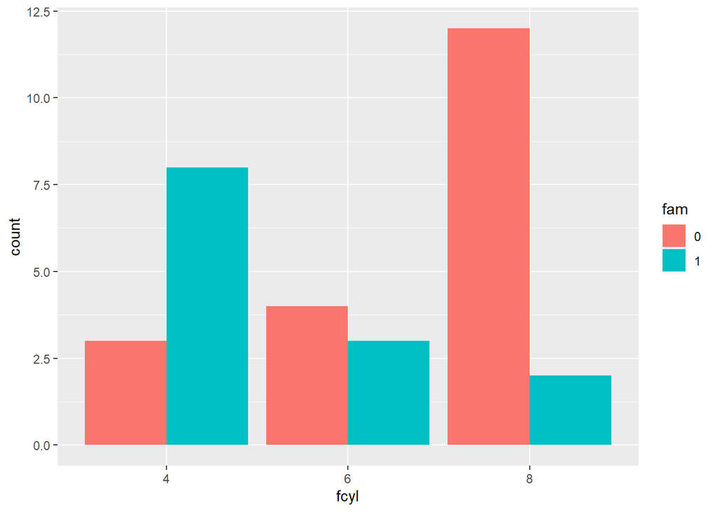

```r
ggplot(mtcars, aes(fcyl,
                   fill = fam)) +
  geom_bar(position = "dodge")
```

- `fill`: to show proportions

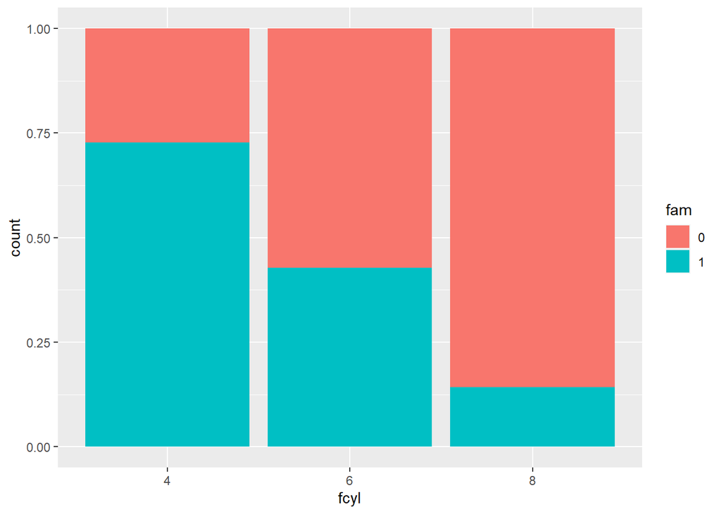

```r
ggplot(mtcars, aes(fcyl,
                   fill = fam)) +
  geom_bar(position = "fill")
```

Customize bar plots further by adjusting the dodging so that the bars partially overlap each other. Instead of using `position = "dodge"`, we can use `position_dodge()` function to specify how much dodging we want.

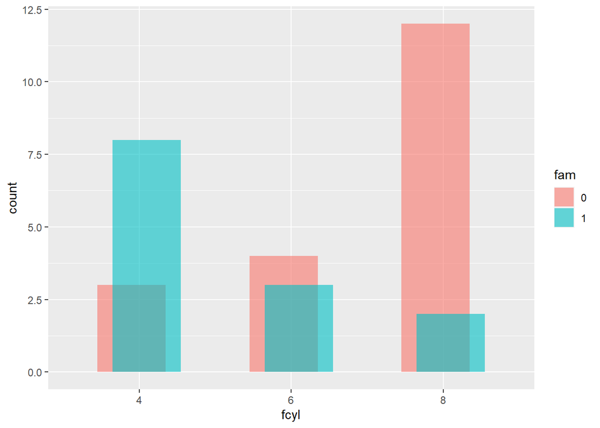

```r
ggplot(mtcars, aes(fcyl,
                   fill = fam)) +
  geom_bar(position = position_dodge(width = 0.2),
           alpha = 0.6)
```

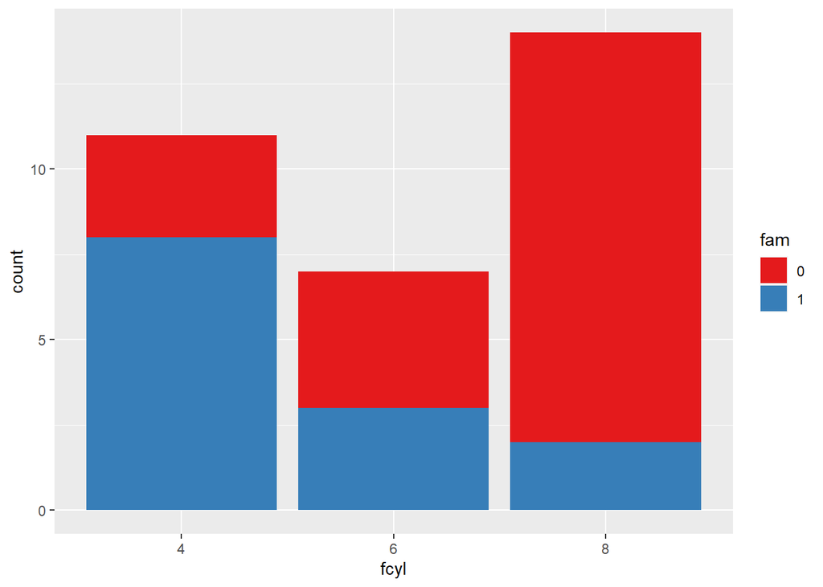

```r
ggplot(mtcars, aes(fcyl, fill = fam)) +
  geom_bar() +
  scale_fill_brewer(palette = "Set1")
```

Plot the `Vocab` dataset with a brewer fill scale, using the default palette:

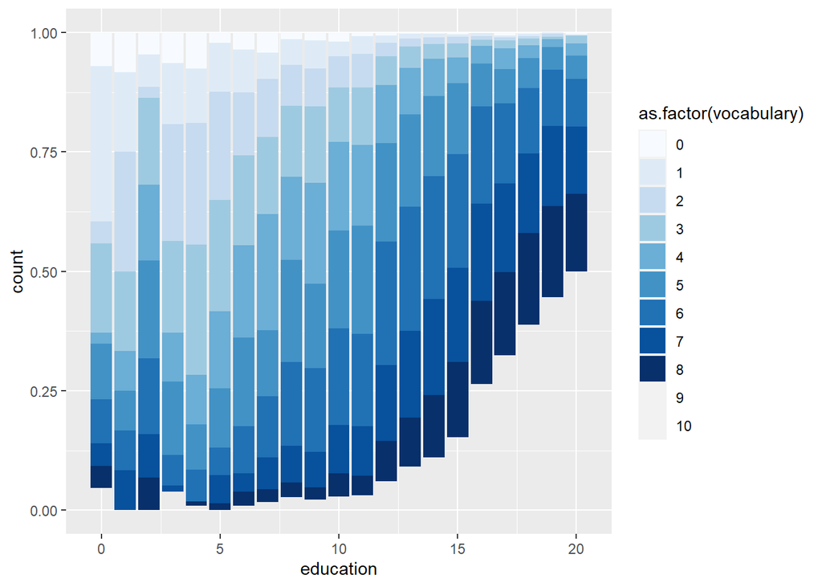

```r
ggplot(Vocab, aes(education,
                  fill = as.factor(vocabulary))) +
  geom_bar(position = "fill") +
  scale_fill_brewer()
```

The function `geom_col()` is just `geom_bar()` where both the `position` and `stat` arguments are set to `identity`. It is used when we want the heights of the bars to represent the exact values in the data.

### 3.5 Line plots

Line plots are very common and well-suited in time series.

Common plot types for line plots:

- `geom_line()`
- `geom_path()`

Load the built-in `beavers` dataset, which contains body temperature series of 2 beavers:

```r
data(beavers)
```

This includes two datasets of two beavers: beaver 1 and 2. Combine them into a larger dataset:

```r
beaver <- rbind(data.frame(beaver1, id = factor("beaver1")),
                data.frame(beaver2, id = factor("beaver2")))
str(beaver)
```

```
## 'data.frame':    214 obs. of  5 variables:
##  $ day  : num  346 346 346 346 346 346 346 346 346 346 ...
##  $ time : num  840 850 900 910 920 930 940 950 1000 1010 ...
##  $ temp : num  36.3 36.3 36.4 36.4 36.5 ...
##  $ activ: num  0 0 0 0 0 0 0 0 0 0 ...
##  $ id   : Factor w/ 2 levels "beaver1","beaver2": 1 1 1 1 1 1 1 1 1 1 ...
```

```r
summary(beaver)
```

```
##       day             time           temp           activ              id
##  Min.   :307.0   Min.   :   0   Min.   :36.33   Min.   :0.0000   beaver1:114
##  1st Qu.:307.0   1st Qu.:1030   1st Qu.:36.85   1st Qu.:0.0000   beaver2:100
##  Median :346.0   Median :1475   Median :36.99   Median :0.0000
##  Mean   :327.9   Mean   :1375   Mean   :37.21   Mean   :0.3178
##  3rd Qu.:346.0   3rd Qu.:1920   3rd Qu.:37.64   3rd Qu.:1.0000
##  Max.   :347.0   Max.   :2350   Max.   :38.35   Max.   :1.0000
```

Plot the body temperature of the two beavers over the time:

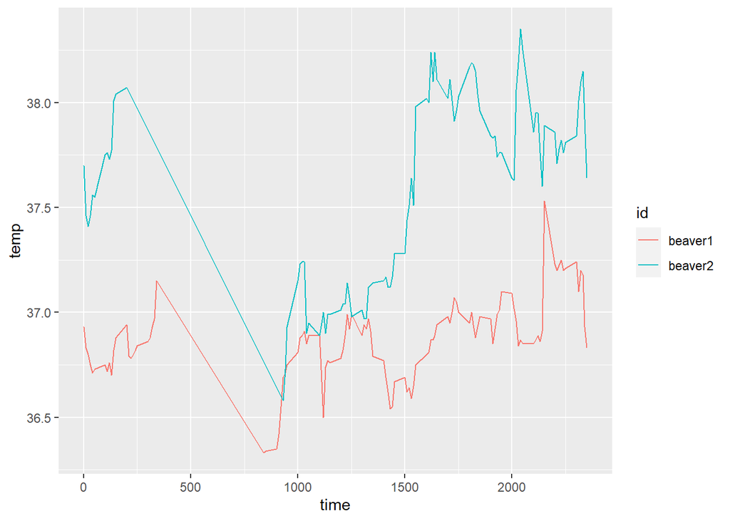

```r
ggplot(beaver, aes(time, temp,
                   col = id)) +
  geom_line()
```

Load the `fish` dataset which contains `fish.species`, `fish.tidy` and `fish.year`:

```r
load("fish.RData")
```

`fish.species` contains the global capture rates of seven salmon species from 1950–2010.

```r
str(fish.species)
```

```
## 'data.frame':    61 obs. of  8 variables:
##  $ Year    : int  1950 1951 1952 1953 1954 1955 1956 1957 1958 1959 ...
##  $ Pink    : int  100600 259000 132600 235900 123400 244400 203400 270119 200798 200085 ...
##  $ Chum    : int  139300 155900 113800 99800 148700 143700 158480 125377 132407 113114 ...
##  $ Sockeye : int  64100 51200 58200 66100 83800 72000 84800 69676 100520 62472 ...
##  $ Coho    : int  30500 40900 33600 32400 38300 45100 40000 39900 39200 32865 ...
##  $ Rainbow : int  0 100 100 100 100 100 100 100 100 100 ...
##  $ Chinook : int  23200 25500 24900 25300 24500 27700 25300 21200 20900 20335 ...
##  $ Atlantic: int  10800 9701 9800 8800 9600 7800 8100 9000 8801 8700 ...
```

Plot the Rainbow Salmon time series:

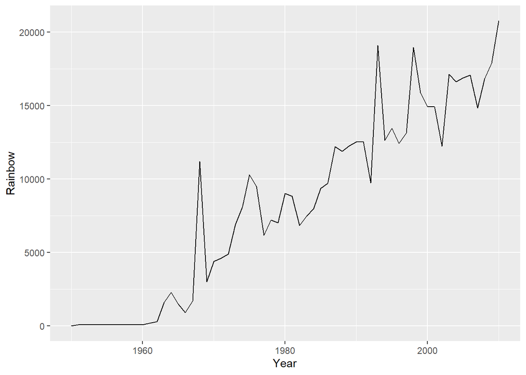

```r
ggplot(fish.species, aes(Year, Rainbow)) +
  geom_line()
```

Plot the Pink Salmon time series:

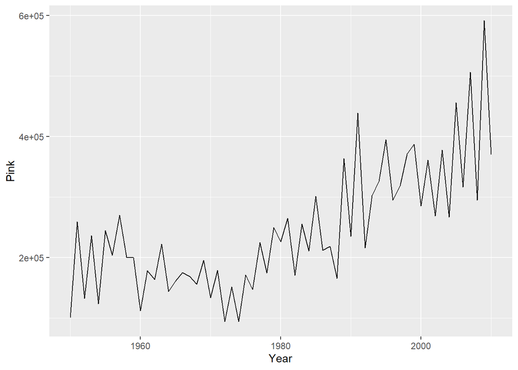

```r
ggplot(fish.species, aes(Year, Pink)) +
  geom_line()
```

`fish.tidy` contains the same data, but in three columns: Species, Year, and Capture:

```r
str(fish.tidy)
```

```
## 'data.frame':    427 obs. of  3 variables:
##  $ Species: Factor w/ 7 levels "Pink","Chum",..: 1 1 1 1 1 1 1 1 1 1 ...
##  $ Year   : int  1950 1951 1952 1953 1954 1955 1956 1957 1958 1959 ...
##  $ Capture: int  100600 259000 132600 235900 123400 244400 203400 270119 200798 200085 ...
```

When there are multiple lines, we have to consider which aesthetics is more appropriate in allowing us to distinguish individual trends.

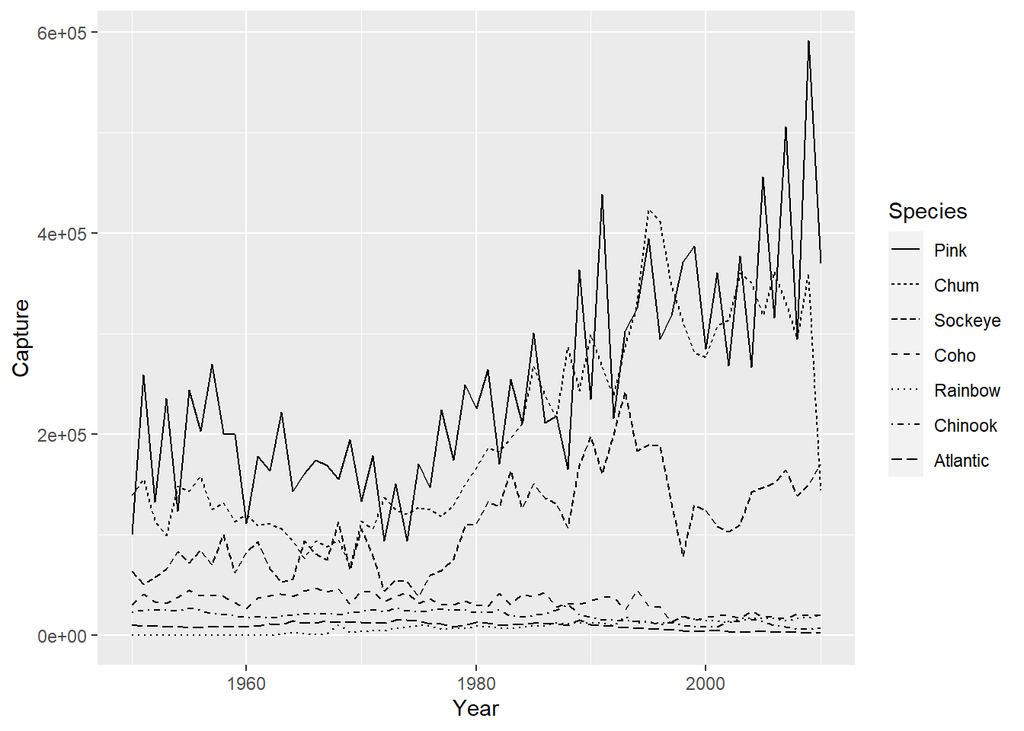

```r
ggplot(fish.tidy, aes(Year, Capture,
                      linetype = Species)) +
  geom_line() # difficult to distinguish.
```

Using size is even worse:

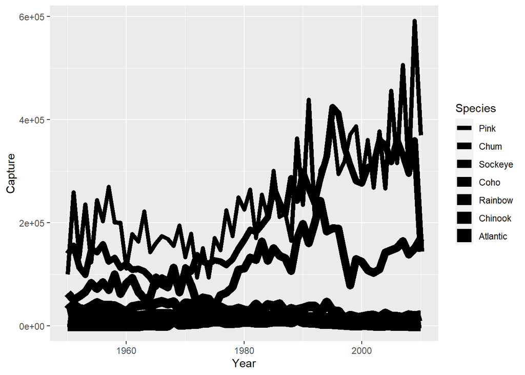

```r
ggplot(fish.tidy, aes(Year, Capture,
                      size = Species)) +
  geom_line()
```

Using color allows for easily distinguishable groups:

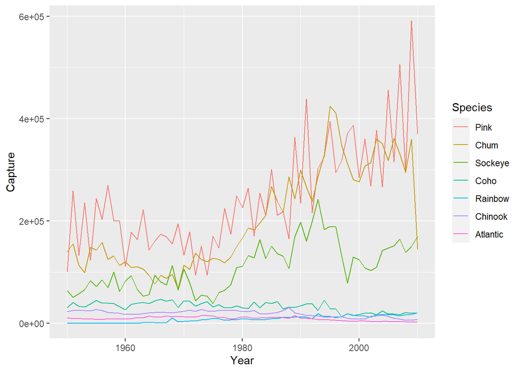

```r
ggplot(fish.tidy, aes(Year, Capture,
                      col = Species)) +
  geom_line()
```

There are a couple of ways of showing lines. The most salient choice is color since it allows the easiest way of distinguishing between each series.

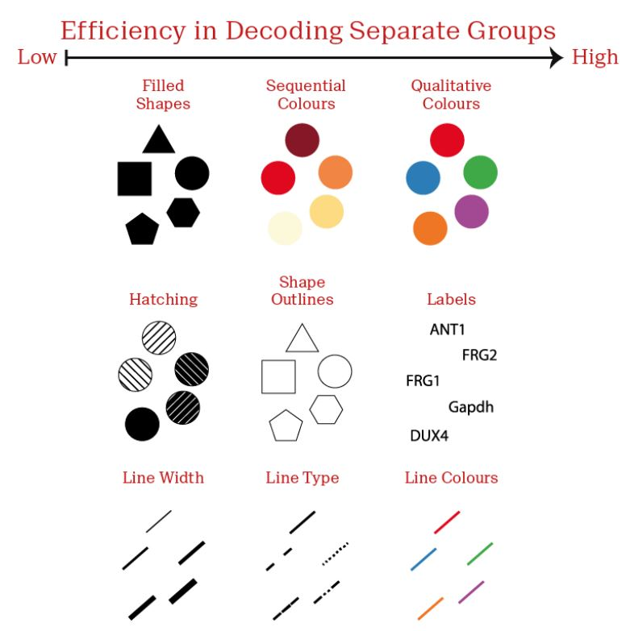

We could also use an area fill with `geom_area()`:

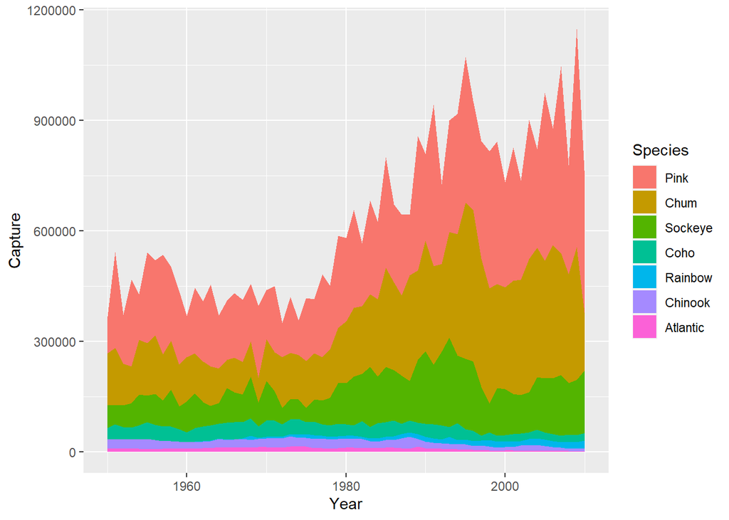

```r
ggplot(fish.tidy, aes(Year, Capture,
                      fill = Species)) +
  geom_area() # default position: stack.
```

This case works. It all depends on how many time series you have and what you want to communicate. If we use “fill” position we got the proportion the total capture for each fish at each time-point. This kind of plot is pretty popular in looking at the proportional trends over time.

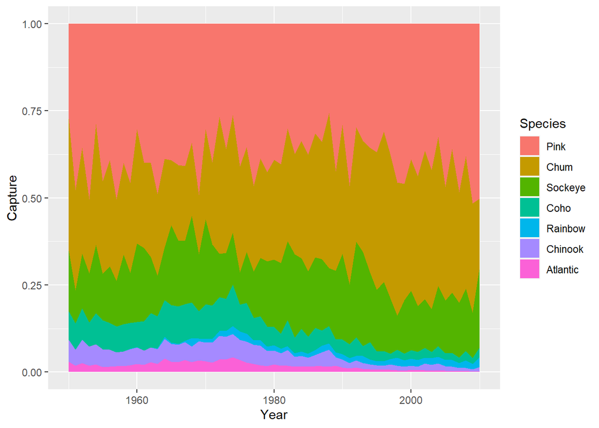

```r
ggplot(fish.tidy, aes(Year, Capture,
                      fill = Species)) +
  geom_area(position = "fill")
```

A difficulty with this kind of plot is that only the bottom and top groups are actually drawn on a common scale, all other ones are irregular shapes so they can be difficult to decipher.

We use `geom_ribbon(`) for overlapping area plot and force the `ymin` to be 0. We need to set the alpha-blending so we can see the overlapping.

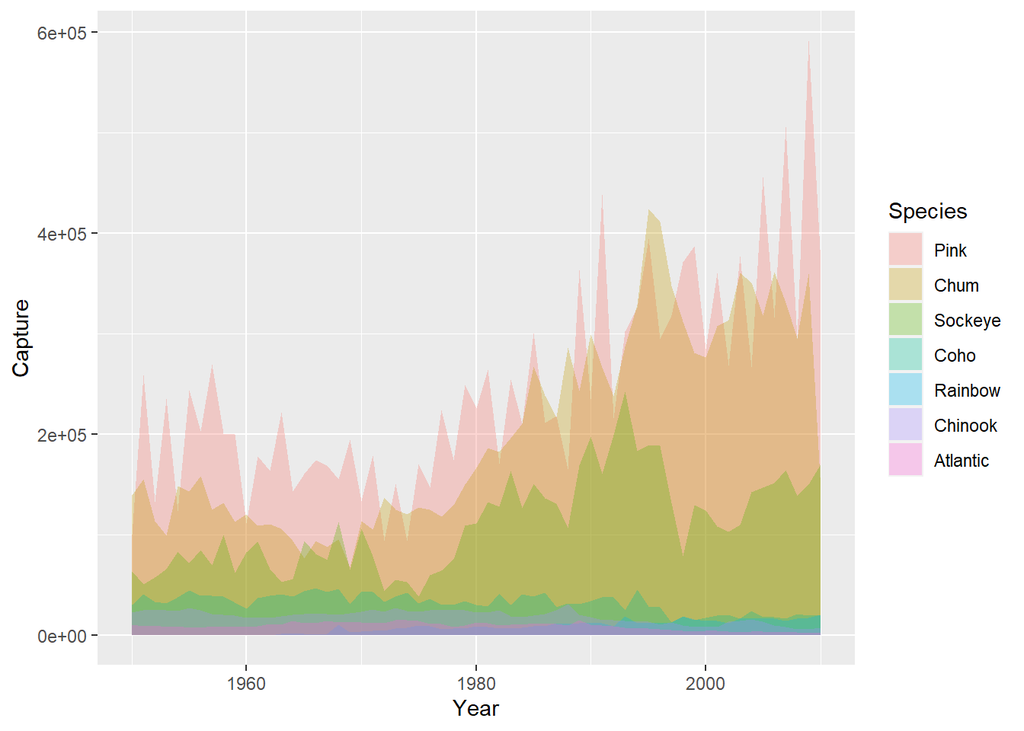

```r
ggplot(fish.tidy, aes(Year, Capture,
                      fill = Species)) +
  geom_ribbon(aes(ymax = Capture,
                  ymin = 0),
              alpha = 0.3)
```